# Statistical Inference Project

JP Dunlap

July 27, 2017

# Part 1: Simulation Exercise

Investigate the exponential distribution in R and compare it with the Central Limit Theorem. The exponential distribution is simulated in R with rexp(n, lambda) where lambda is the rate parameter. The mean of exponential distribution is 1/lambda and the standard deviation is also 1/lambda. Set lambda = 0.2 for all of the simulations. Investigate the distribution of averages of 40 exponentials. Conduct 1000 simulations.

## Discussion

The exponential distribution is the probability distribution in which events occur continuously and independently based on a constant rate of change. It describes the time between events in a Poisson process (https://en.wikipedia.org/wiki/Exponential_distribution).

The exponential distribution has a theoretical mean and standard deviation equal to 1/lambda, where lambda is the rate of change in the underlying Poisson process. This means that the shape of the exponential distribution is completely dependent on the rate of change (lambda) as illustrated in this plot.

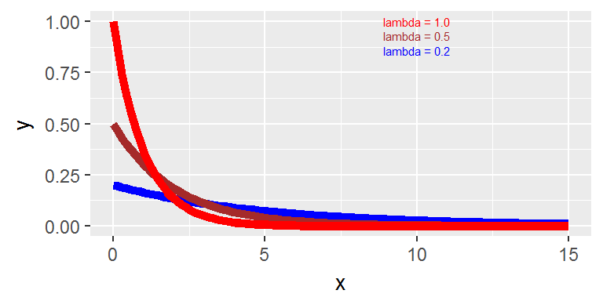

The impact of the changes in lambda are clear from the above chart.

## Simulation

The task at hand is to simulate 1000 exponential distributions with 40 observations each to determine of the Central Limit Theorem is support for exponential distributions. That is, test the distribution of the means and standard deviations of 1000 simulations of of 40 values from taken from an exponential distribution with Lambda = 0.20, to determine if they approximate the theoretical mu and sigma of the distribution, 1/lambda = 1/0.20 = 5.

If the CLT holds, one would expect to see the mean of the simulated means and the mean of the simulated standard deviations to be approximately equal to the theoretical value of 5 (1/lambda = 1/.2 = 5.0). The actual calculated mean of the simulated means is 5.0108542, and the calculated mean of the simulated standard deviations is 4.8833921.

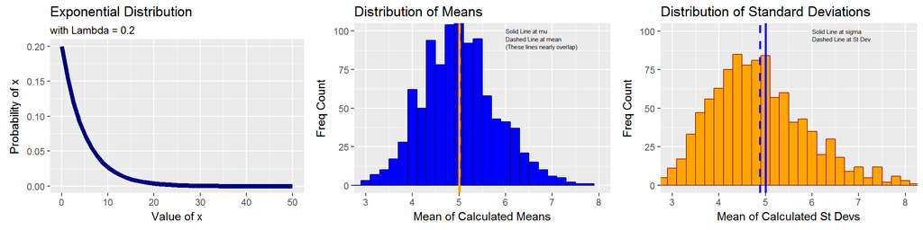

## Part 1 Conclusion

However, both the calculated statistics and the two histograms show what appears to be a far more Gaussian distribution of the mean and of the standard deviation about the theoretical values of 5 for both mu and sigma. It appears reasonable to conclude that the Central Limit Theorem holds in the case of exponential distributions.

The actual calculated mean of the simulated means is 5.0108542 compared to a theoretical value of 5.0. The calculated mean of the simulated standard deviations is 4.8833921 compared to a theoretical value of 5.0.

# Part 2: Basic Inferential Data Analysis

In 1947 E.W. Crampton published “The growth of the odontoblast of the incisor teeth as a criterion of vitamin C intake of the guinea pig” in the Journal of Nutrition. (see Crampton, E. W. (1947) The growth of the odontoblast of the incisor teeth as a criterion of vitamin C intake of the guinea pig. The Journal of Nutrition 33(5): 491–504. http://jn.nutrition.org/content/33/5/491.full.pdf). In his paper he discussed the impact of two different forms of vitamin C, administered in three does levels, on tooth growth in Guinea Pigs.

The research design utilized 60 Guinea Pigs each of which was administered Vitamin C either in the form of orange juice (coded OJ), or ascorbic acid (coded as VC). Withing the two groups the animals were further divided into three group based on dosage (0.5, 1, or 2 mg/day). The length of the odontoblasts were then measured (presumably in microns).

This analysis will attempt to determine the impact of the various delivery methods/dosages on the length of the odontoblasts.

## Research Assumptions

The analysis and conclusions for this research are based on the following assumptions:

1. All animals in the study come from the same population of Guinea Pigs
2. Animals are randomly assigned to each of the six possible treatment groups
3. The growth or odondoblasts is normally distributed with an unknown mu and sigma

## Data Mangement

As the ToothGrowth database is a part of the R package installation it needs only to be loaded in order for analysis to be conducted. A frequency graph of the odontoblast length for each possible combination is shown.

## Exploratory Data Analysis - Examining Confidence Intervals

The first step is to examine the data grouped by the two effect variables, dose and delivery method. A histogram of each combination is shown below. Layering the upper and lower confidence intervals may provide some insight.

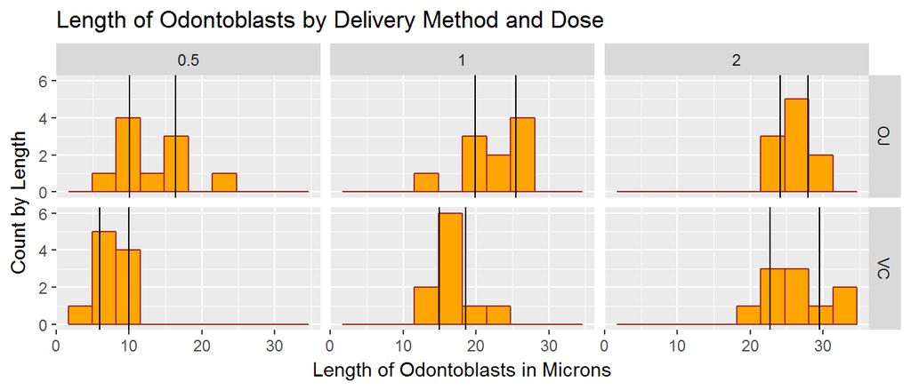

Examining the histograms with the 95% confidence interval shown suggests that there may be a significant effect from the delivery method at the lower two doses (0.5, and 1,0 mg/day). The method does not appear to be a significant effect at the higher does of 2.0mg/day.

Examining the actual lower and upper confidence intervals will provide additional insight.

| Delivery.Meth | LowerBound | UpperBound |
| --- | --- | --- |
| **Dose 0.5 mg/day** |  |  |
| OJ | 10.039717 | 16.420283 |
| VC | 6.015176 | 9.944824 |
| **Dose 1.0 mg/day** |  |  |
| OJ | 19.902273 | 25.497727 |
| VC | 14.970657 | 18.569343 |
| **Dose 2.0 mg/day** |  |  |
| OJ | 24.160686 | 27.959314 |
| VC | 22.707910 | 29.572090 |

#### By Dosing Levels

Looking at a comparison of the CI bounds by dosing level may help to better understand the potential differences.

**Dose at 0.50 mg/day** The confidence interval for the two delivery methods shows no overlap between the two. This seems to suggest that at the dose level of 0.50 mg/day, the delivery method does make a difference.

**Dose at 1.0 mg/day** Similarly the confidence interval for the two delivery methods shows no overlap between the two. This seems to suggest that at the dose level of 1.0 mg/day, the delivery method does make a difference.

**Dose at 2.0 mg/day** By contrast, The confidence interval for the two delivery methods shows a complete overlap between the two. This suggest that at the dose level of 2.0 mg/day, the delivery method no longer seems make a difference.

| Dose | LowerBound | UpperBound |
| --- | --- | --- |
| **Orange Juice** |  |  |
| 0.5 | 10.039717 | 16.420283 |
| 1.0 | 19.902273 | 25.497727 |
| 2.0 | 24.160686 | 27.959314 |
| **Ascorbic Acid** |  |  |
| 0.5 | 6.015176 | 9.944824 |
| 1.0 | 14.970657 | 18.569343 |
| 2.0 | 22.707910 | 29.572090 |

#### By Delivery Method

Looking at a comparison of the CI bounds by dosing level may help to better understand the potential differences.

**Delivery Method - Orange Juice** The confidence interval for the three dose amounts shows no overlap between the lower two level, and a small overlap between the upper two. This seems to suggest that effect of the minimal dose of orange juice is less than the middle and higher dose, but that the effect between the middle and higher dose are less clear.

**Delivery Method - Ascorbic Acid** For ascorbic acid, the confidence interval for the three dose level shows no overlap at all. This seems to suggest that for ascorbic acid the size of the dose has a significant effect on growth.

### Conducting Hypotheses Testing Using Students T-Test

T-tests are a traditional small sample statistic to examine the difference between two samples, in this case, taken from the same population. In the case of this data set, the comparison is between the various combinations of dose rate and delivery method. Note that it would also be appropriate to use other statistical tests such as one-way and two-way analysis of variance to explore these relationships, these techniques are outside of the scope of this project.

#### Hypotheses Test Group 1 - Comparing Delivery Method within Dose Amounts

##### H_0: mean_OJ EQ mean_VC - for each dosing amount

##### H-a: mean_OJ NE mean_vc - for each dosing amount

The first set of analyses include the comparison of delivery method by dosing amount. The mean length of Odontoblasts are compared with dose held constant and delivery method compared. The following table summarizes these results.

| Test_Conducted | tvalue | pvalue | Significant | Bonferroni | BH |
| --- | --- | --- | --- | --- | --- |
| H_0: mean_OJ = mean_VC - Dose = 0.5 mg/day | 3.170 | 0.0053 | TRUE | 0.015900 | 0.007950 |
| H_0: mean_OJ = mean_VC - Dose = 1.0 mg/day | 4.033 | 0.000781 | TRUE | 0.002343 | 0.002343 |
| H_0: mean_OJ = mean_VC - Dose = 2.0 mg/day | -0.0461 | 0.964 | FALSE | 1.000000 | 0.964000 |

From these data it appears that the two different delivery methods due vary in effectiveness at lower and medium doses (0.5 and 1.0 mg/day) with Orange Juice appearing more effective. At the higher dose of 2.0 mg/day, the effect is not found.

Both the Bonferroni correction to correct for the Family-Wise Error Rate, and the Benjamini-Hochberg Correction to correct for False Discovery Rate, were applied to the results. While both correction do change the p-value, there are no changes to the impact of the results. Given that there are only three tests conducted, this is not surprising.

As a result we are able to reject the null hypothesis at dosing levels 0.5 and 1.0 mg/day. The null hypothesis is not rejected for the dosing level at 2.0 mg/day.

#### Hypotheses Test Group 2 - Comparing Dosing Combinations within Delivery Method

##### H_0: mean_dosea EQ mean_doseb - for each possbile pair of dosing amount holding delivery method constant

##### H-a: mean_dosea NE mean_doseb - for each possbile pair of dosing amount holding delivery method constant

The second set of hypotheses include the comparison of dosage pairs by delivery method. The mean length of Odontoblasts are compared with delivery method held constant and pairs of dosage amounts compared (i.e., 0.5 to 1.0, 0.5 to 2.0, and 1.0 to 2.0). In all there are six possible sets of hypotheses.

The following table summarizes these results.

| Test_Conducted | tvalue | pvalue | Significant | Bonferroni | BH |
| --- | --- | --- | --- | --- | --- |
| H_0: mean_dosea = mean_doseb - 0.5 to 1.0 mg/day, with Orange Juice delivery | -5.049 | 0.0000836 | TRUE | 0.0005016000 | 0.0001003200 |
| H_0: mean_dosea = mean_doseb - 0.5 to 2.0 mg/day, with Orange Juice delivery | -7.817 | 0.00000034 | TRUE | 0.0000020400 | 0.0000010200 |
| H_0: mean_dosea = mean_doseb - 1.0 to 2.0 mg/day, with Orange Juice delivery | -2.248 | 0.0374 | TRUE | 0.2244000000 | 0.0374000000 |
| H_0: mean_dosea = mean_doseb - 0.5 to 1.0 mg/day, with Ascorbic Acid delivery | -7.463 | 0.000000649 | TRUE | 0.0000038940 | 0.0000012980 |
| H_0: mean_dosea = mean_doseb - 0.5 to 2.0 mg/day, with Ascorbic Acid delivery | -10.388 | 0.00000000496 | TRUE | 0.0000000298 | 0.0000000298 |
| H_0: mean_dosea = mean_doseb - 1.0 to 2.0 mg/day, with Ascorbic Acid delivery | -5.470 | 0.000034 | TRUE | 0.0002040000 | 0.0000510000 |

Again, the Bonferroni correction to correct for the Family-Wise Error Rate, and the Benjamini-Hochberg Correction to correct for False Discovery Rate, were applied to the results. Examining the False Discovery Rate correction, there are no important changes. However, when correcting the Family-Wise Error Rate, one of the six tests, Orange Juice compared at 1.0 to 2.0 did fall above the alpha = 0.05 cutoff level.

It is reasonable to reject the null hypothesis in each of the six possible pairings, based on the individual t-tests, suggesting that dose rates do make a difference. However when applying the correction for Family-Wise Error Rate, it would be reasonable to fail to reject the null hypothesis comparing 1.0 to 2.0 mg/day dosing via Orange Juice delivery.

## Part 2 Conclusion

The of the confidence interval analysis and the hypotheses testing (t-test) analyses are essentially the same. As a result, it is reasonable to conclude that increasing dosage of both ascorbic acid and orange juice above a minimum amount is effective in increasing odontoblast length. At the highest dose, there is no indicated difference in the delivery method.

When comparing the various dosage pairs, all appear to have a significant impact, regardless of delivery method. However the Bonferroni correction for Family-Wise Error Rate does call one effect into question.